# Exploratory Data Analysis Final Project

Twiesha Vachhrajani

April 8, 2019

# Final Project Report

## Questions posed

The questions arising from a perusal of the data are: 1. Are the total sales related to the trail the bike is appropriate for? 2. Is there a significant difference between the sales of aluminium frame bikes and carbon frame bikes? 3. Is there a relationship between the price of the bike and sale numbers in these 30 stores?

## Data Analysis

In order to evaluate the data, we must first set the working directory and import the data using the read.csv function.

Once this data is imported, we look to the summary of the data using both the str function, which shows us the types of data characters in each column, and the summary function, which shows the number of values and the quartiles.

```r
bikevendors <- read.csv("bikeVendors.csv")
summary(bikevendors)
```

```
##                  model       category1               category2
##  Bad Habit 1        : 1   Mountain:51   Elite Road        :21
##  Bad Habit 2        : 1   Road    :46   Cross Country Race:19
##  Beast of the East 1: 1                 Endurance Road    :16
##  Beast of the East 2: 1                 Trail             :13
##  Beast of the East 3: 1                 Sport             : 9
##  CAAD Disc Ultegra  : 1                 Over Mountain     : 8
##  (Other)            :91                 (Other)           :11
##       frame        price       Albuquerque.Cycles Ann.Arbor.Speed
##  Aluminum:40   Min.   :  415   Min.   :0.000000   Min.   :0.000000
##  Carbon  :57   1st Qu.: 1950   1st Qu.:0.003497   1st Qu.:0.003322
##                Median : 3200   Median :0.006993   Median :0.009967
##                Mean   : 3954   Mean   :0.010309   Mean   :0.010309
##                3rd Qu.: 5330   3rd Qu.:0.013986   3rd Qu.:0.014950
##                Max.   :12790   Max.   :0.048951   Max.   :0.033223
##
##  Austin.Cruisers    Cincinnati.Speed   Columbus.Race.Equipment
##  Min.   :0.000000   Min.   :0.000000   Min.   :0.000000
##  1st Qu.:0.004065   1st Qu.:0.002558   1st Qu.:0.005076
##  Median :0.008130   Median :0.010230   Median :0.010152
##  Mean   :0.010309   Mean   :0.010309   Mean   :0.010309
##  3rd Qu.:0.016260   3rd Qu.:0.015345   3rd Qu.:0.012690
##  Max.   :0.052846   Max.   :0.033248   Max.   :0.038071
##
##  Dallas.Cycles      Denver.Bike.Shop    Detroit.Cycles
##  Min.   :0.000000   Min.   :0.0004346   Min.   :0.000000
##  1st Qu.:0.004274   1st Qu.:0.0073881   1st Qu.:0.005952
##  Median :0.008547   Median :0.0104302   Median :0.009921
##  Mean   :0.010309   Mean   :0.0103093   Mean   :0.010309
##  3rd Qu.:0.012821   3rd Qu.:0.0134724   3rd Qu.:0.013889
##  Max.   :0.042735   Max.   :0.0256410   Max.   :0.029762
##
##  Indianapolis.Velocipedes Ithaca.Mountain.Climbers Kansas.City.29ers
##  Min.   :0.000000         Min.   :0.000000         Min.   :0.0002881
##  1st Qu.:0.003135         1st Qu.:0.002373         1st Qu.:0.0072025
##  Median :0.006270         Median :0.010285         Median :0.0100835
##  Mean   :0.010309         Mean   :0.010309         Mean   :0.0103093
##  3rd Qu.:0.015674         3rd Qu.:0.016614         3rd Qu.:0.0132527
##  Max.   :0.050157         Max.   :0.027690         Max.   :0.0247767
##
```

[output cut: 41 more lines]

```
##  Min.   :0.000000       Min.   :0.000000       Min.   :0.000000
##  1st Qu.:0.002674       1st Qu.:0.000000       1st Qu.:0.000000
##  Median :0.008021       Median :0.007812       Median :0.004854
##  Mean   :0.010309       Mean   :0.010309       Mean   :0.010309
##  3rd Qu.:0.016043       3rd Qu.:0.015625       3rd Qu.:0.014563
##  Max.   :0.042781       Max.   :0.054688       Max.   :0.048544
##
##  Wichita.Speed
##  Min.   :0.000000
##  1st Qu.:0.003945
##  Median :0.009862
##  Mean   :0.010309
##  3rd Qu.:0.015779
##  Max.   :0.047337
##
```

```r
str(bikevendors)
```

```
## 'data.frame':    97 obs. of  35 variables:
##  $ model                       : Factor w/ 97 levels "Bad Habit 1",..: 1 2 3 4 5 6 7 8 9 10 ...
##  $ category1                   : Factor w/ 2 levels "Mountain","Road": 1 1 1 1 1 2 2 2 2 2 ...
##  $ category2                   : Factor w/ 9 levels "Cross Country Race",..: 8 8 8 8 8 3 3 3 3 3 ...
##  $ frame                       : Factor w/ 2 levels "Aluminum","Carbon": 1 1 1 1 1 1 1 1 1 1 ...
##  $ price                       : int  3200 2660 2770 2130 1620 2660 1680 5860 1950 4260 ...
##  $ Albuquerque.Cycles          : num  0.01748 0.00699 0.01049 0.01049 0.0035 ...
##  $ Ann.Arbor.Speed             : num  0.00664 0.00997 0.01495 0.00997 0.00332 ...
##  $ Austin.Cruisers             : num  0.00813 0.00407 0.00813 0.00813 0 ...
##  $ Cincinnati.Speed            : num  0.00512 0 0 0 0 ...
##  $ Columbus.Race.Equipment     : num  0.01015 0 0 0.00508 0.00254 ...
##  $ Dallas.Cycles               : num  0.01282 0.01709 0.00427 0.00427 0.00427 ...
##  $ Denver.Bike.Shop            : num  0.0117 0.0139 0.0183 0.0152 0.0169 ...
##  $ Detroit.Cycles              : num  0.00992 0.01587 0.0119 0.00595 0.0119 ...
##  $ Indianapolis.Velocipedes    : num  0.00627 0.00313 0.0094 0.0094 0 ...
```

[output cut: 21 more lines]

We can check the number of rows using the rnow function which gives us a result of 97, and the columns using the ncol function which gives us the result of 35. The codes can be found below.

```r
nrow(bikevendors)
```

```
## [1] 97
```

```r
ncol(bikevendors)
```

```
## [1] 35
```

Before proceeding, we must check for missing data. This can be done by checking for the total number of missing values.

```r
sum(is.na(bikevendors))
```

```
## [1] 0
```

We see that no values are missing.

```r
bikevendors$Total <- rowSums( bikevendors[,6:35] )
df1 <- bikevendors
df1 <- df1[, -1]
df1 <- df1[, -2]
df1 <- df1[, -c(2:3)]
head(df1)
```

```
##   category1 Albuquerque.Cycles Ann.Arbor.Speed Austin.Cruisers
## 1  Mountain        0.017482517     0.006644518     0.008130081
## 2  Mountain        0.006993007     0.009966777     0.004065041
## 3  Mountain        0.010489510     0.014950166     0.008130081
## 4  Mountain        0.010489510     0.009966777     0.008130081
## 5  Mountain        0.003496503     0.003322259     0.000000000
## 6      Road        0.013986014     0.026578073     0.020325203
##   Cincinnati.Speed Columbus.Race.Equipment Dallas.Cycles Denver.Bike.Shop
## 1       0.00511509             0.010152284   0.012820513       0.01173403
## 2       0.00000000             0.000000000   0.017094017       0.01390700
## 3       0.00000000             0.000000000   0.004273504       0.01825293
## 4       0.00000000             0.005076142   0.004273504       0.01521078
## 5       0.00000000             0.002538071   0.004273504       0.01694915
## 6       0.01534527             0.010152284   0.000000000       0.01086484
##   Detroit.Cycles Indianapolis.Velocipedes Ithaca.Mountain.Climbers
```

[output cut: 55 more lines]

In order to ease our analysis, we can first rename Category 1 to terrain, use the total sales column for all the sales of a particular bike (created above), and then plot a chart to see a relationship between the terrain and sales.

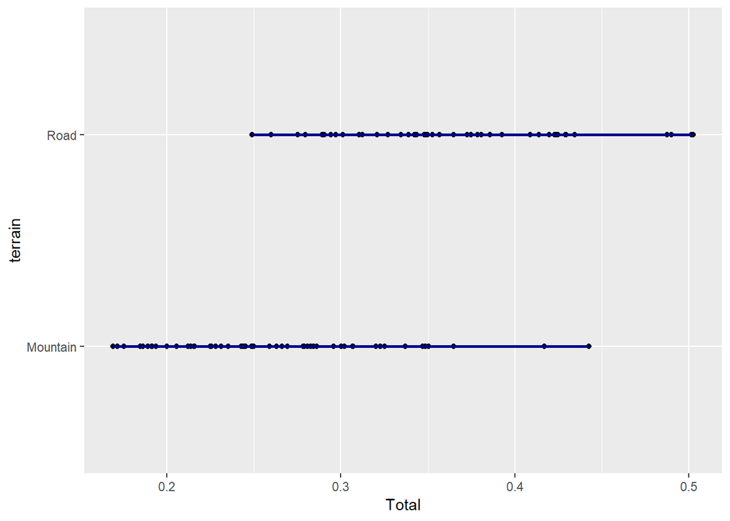

```r
names(df1)[1] <- "terrain"
library(ggplot2)
p <- ggplot() +
  geom_point(data = df1, aes(x=Total, y=terrain)) +
  geom_smooth(data=df1, aes(x=Total, y=terrain), fill="blue",
              colour="darkblue", size=1)
plot(p)
```

This shows a clear relation between the terrain and sales, showing that the bikes made for the roads have much more total sales than bikes for mountain terrains.

Next, to answer our second question, we look at the total sales of carbon fiber bikes and aluminium bikes. To do this, we will first create a new column titled Total, so we have the total sales. Then we will create new dataframes for carbon bikes and aluminium bikes.

```r
bikevendors$Total <- rowSums( bikevendors[,6:35] )
library(dplyr)
carbon <- filter(bikevendors, bikevendors$frame == "Carbon")
head(carbon)
```

```
##              model category1          category2  frame price
## 1  F-Si Black Inc.  Mountain Cross Country Race Carbon 11190
## 2    F-Si Carbon 2  Mountain Cross Country Race Carbon  4800
## 3    F-Si Carbon 4  Mountain Cross Country Race Carbon  2880
## 4    F-Si Hi-Mod 1  Mountain Cross Country Race Carbon  6390
## 5 F-Si Hi-Mod Team  Mountain Cross Country Race Carbon  9060
## 6   Habit Carbon 1  Mountain              Trail Carbon  7460
##   Albuquerque.Cycles Ann.Arbor.Speed Austin.Cruisers Cincinnati.Speed
## 1        0.000000000     0.000000000     0.000000000      0.007672634
## 2        0.017482517     0.001661130     0.004065041      0.007672634
## 3        0.010489510     0.009966777     0.016260163      0.000000000
## 4        0.003496503     0.000000000     0.000000000      0.023017903
## 5        0.006993007     0.000000000     0.004065041      0.007672634
## 6        0.003496503     0.000000000     0.000000000      0.005115090
##   Columbus.Race.Equipment Dallas.Cycles Denver.Bike.Shop Detroit.Cycles
```

[output cut: 62 more lines]

```r
aluminum<- filter(bikevendors, bikevendors$frame == "Aluminum")
head(aluminum)
```

```
##                 model category1  category2    frame price
## 1         Bad Habit 1  Mountain      Trail Aluminum  3200
## 2         Bad Habit 2  Mountain      Trail Aluminum  2660
## 3 Beast of the East 1  Mountain      Trail Aluminum  2770
## 4 Beast of the East 2  Mountain      Trail Aluminum  2130
## 5 Beast of the East 3  Mountain      Trail Aluminum  1620
## 6   CAAD Disc Ultegra      Road Elite Road Aluminum  2660
##   Albuquerque.Cycles Ann.Arbor.Speed Austin.Cruisers Cincinnati.Speed
## 1        0.017482517     0.006644518     0.008130081       0.00511509
## 2        0.006993007     0.009966777     0.004065041       0.00000000
## 3        0.010489510     0.014950166     0.008130081       0.00000000
## 4        0.010489510     0.009966777     0.008130081       0.00000000
## 5        0.003496503     0.003322259     0.000000000       0.00000000
## 6        0.013986014     0.026578073     0.020325203       0.01534527
##   Columbus.Race.Equipment Dallas.Cycles Denver.Bike.Shop Detroit.Cycles
```

[output cut: 62 more lines]

We can then edit our new datasets to include only the frame type and the total sales, to make it easier to plot using bar plots.

```r
keeps <- c("frame", "Total")
carbon1 = carbon[keeps]
head(carbon1)
```

```
##    frame     Total
## 1 Carbon 0.2158789
## 2 Carbon 0.2353880
## 3 Carbon 0.3487127
## 4 Carbon 0.1690995
## 5 Carbon 0.1912802
## 6 Carbon 0.1847975
```

```r
keeps <- c("frame", "Total")
aluminum1 = aluminum[keeps]
head(aluminum1)
```

```
##      frame     Total
## 1 Aluminum 0.3470381
## 2 Aluminum 0.2429168
## 3 Aluminum 0.3021513
## 4 Aluminum 0.3201535
## 5 Aluminum 0.2499492
## 6 Aluminum 0.3785810
```

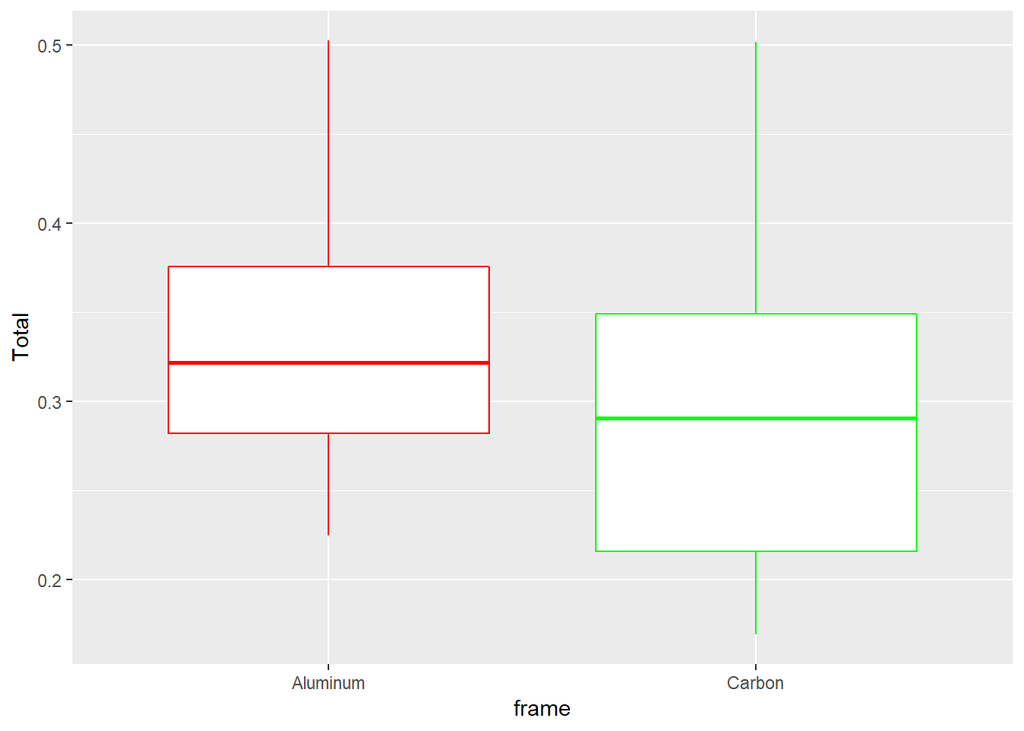

```r
ggplot() +
  geom_boxplot(data=carbon1, aes(x=frame, y=Total), color='green') +
  geom_boxplot(data=aluminum1, aes(x=frame, y=Total), color='red')
```

Turning to our third questions, we look at the relationship between the price of the bike and the sales numbers. First, we can make a new column combining the total sales, names Total.

```r
bikevendors$Total <- rowSums( bikevendors[,6:35] )
head(bikevendors$Total)
```

```
## [1] 0.3470381 0.2429168 0.3021513 0.3201535 0.2499492 0.3785810
```

Then, we can plot the new column, Total, against the price column, to see whether the price affects the total sales.

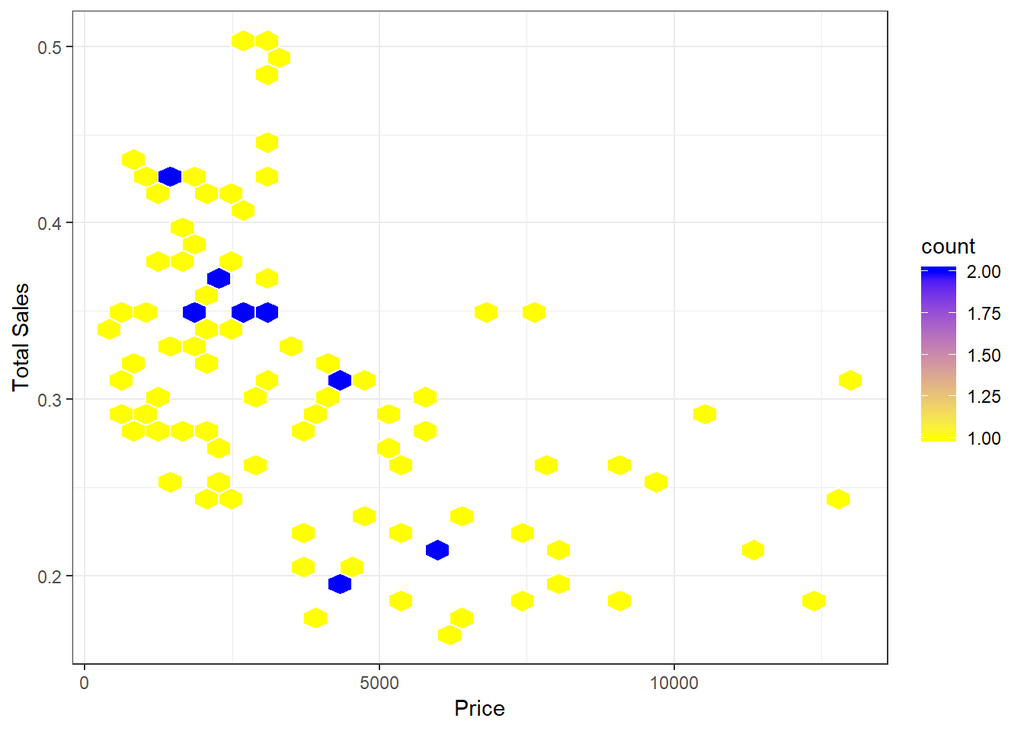

```r
ggplot(bikevendors, (aes(x=price, y=Total))) +
  stat_binhex(colour="white") +
  theme_bw() +
  scale_fill_gradient(low="yellow", high="blue") +
  labs(x="Price", y="Total Sales")
```

This concludes the exploratory data analysis of the Bike Vendors file.